# Лабораторная работа №7: Презентация на базе Beamer

Дисциплина: Компьютерный практикум по научному письму

ДАБВАН ЛУАИ МОХАММЕД АЛИ, НФИмд-01-24, 1032249837

Российский университет дружбы народов, Москва, Россия

06 декабря 2025

## Преподаватель

**ФИО:** Кулябов Дмитрий Сергеевич **Должность:** Профессор кафедры прикладной информатики и теории вероятностей РУДН **Дисциплина:** Компьютерный практикум по научному письму

## Информация о докладчике

Дабвван Луаи Мохаммед Али Студент 2 курса Направление: 02.04.02 Фундаментальная информатика и информационные технологии (магистратура) Российский университет дружбы народов

# Вводная часть

### Актуальность темы:

В этом работа мы изучаем, как создать презентации с использованием Beamer в LaTeX. Это важная тема, потому что LaTeX является мощным инструментом для создания научных презентаций, которые требуют точности и профессионального оформления, особенно в математике и научных дисциплинах.

### Объект и предмет исследования:

Объект исследования: это использование Beamer для создания научных презентаций в LaTeX. Предмет исследования: это методы, возможности и преимущества Beamer по сравнению с другими инструментами, такими как PowerPoint, для создания научных презентаций.

### Научная новизна:

Научная новизна заключается в использовании Beamer как инструмента для создания научных презентаций, что позволяет достичь высокой точности в оформлении и легкости в создании слайдов, включая математические формулы, изображения и таблицы.

### Практическая значимость:

Практическая значимость заключается в том, что использование Beamer в LaTeX значительно ускоряет процесс создания презентаций для научных конференций, лекций и других мероприятий, обеспечивая при этом высокий уровень качества и точности.

# Цель работы , задачи и гипотеза

## Цель работы:

Цель работы — изучить возможности использования Beamer в LaTeX для создания научных презентаций .

## Гипотеза:

Мы предполагаем, что использование Beamer для создания научных презентаций может быть более эффективным и удобным по сравнению с другими инструментами, такими как PowerPoint, благодаря его интеграции с LaTeX и возможностью создания профессиональных слайдов с математическими формулами и таблицами.

## Задачи работы:

1. Изучить основы Beamer и его функциональные возможности.
2. Создать пример научной презентации с использованием Beamer.
3. Оценить преимущества и недостатки Beamer на практике.

## Материалы и методы

В качестве теоретической базы использовался раздел «LaTeX presentations» из пособия Practical scientific writing

# Содержание исследования

## 1.Предлагаемое решение задач исследования с обоснованием

Решение задач исследования заключалось в использовании Beamer для создания научных презентаций. Это решение обосновано тем, что Beamer обеспечивает высокую точность в оформлении и позволяет автоматически организовывать слайды с необходимыми элементами, такими как формулы и изображения.

# 2.Основные этапы работы

## Создание Содержание

```latex
\begin{frame}{Содержание}
\tableofcontents
\end{frame}
```

## Результат:

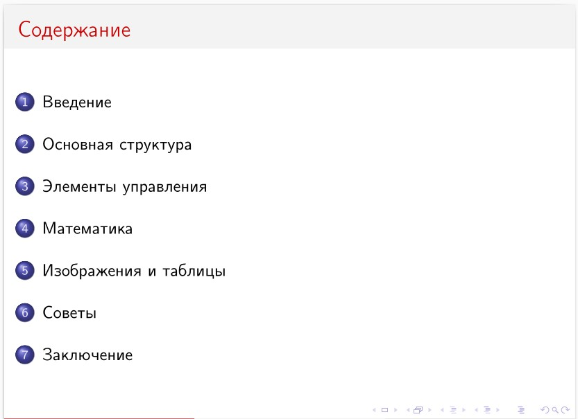

## Основная структура — Структура документа Beamer

```latex
\section{Основная структура}
\begin{frame}{Структура документа Beamer}
\begin{exampleblock}{Упрощенный пример}
{\tiny
\texttt{\textbackslash documentclass\{beamer\}}\\
\texttt{\textbackslash begin\{document\}}\\
\texttt{\textbackslash begin\{frame\}\{Заголовок\}}\\
\texttt{Содержание слайда}\\
\texttt{\textbackslash end\{frame\}}\\
\texttt{\textbackslash end\{document\}}
}
\end{exampleblock}
\vspace{0.3cm}

\begin{alertblock}{Важно}
Каждый слайд должен быть внутри окружения \texttt{frame}.
\end{alertblock}
\end{frame}
```

## Результат:

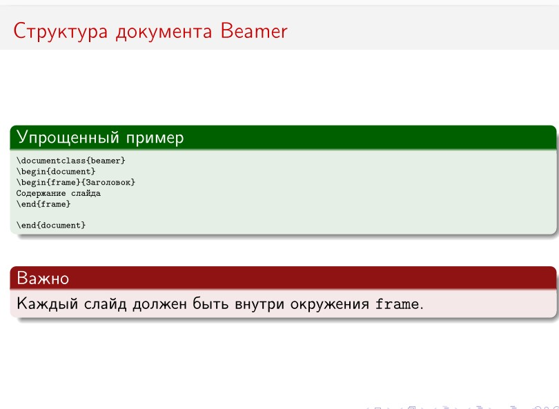

## Элементы управления — Контроль отображения

```latex
\section{Элементы управления}
\begin{frame}{Контроль отображения}
\begin{itemize}
\item Первый элемент
\pause
\item Второй элемент
\pause
\item Третий элемент
\end{itemize}

\pause

\begin{block}{Блок после паузы}
Объяснение: В этом слайде я использовал команду. Она
позволяет показывать элементы на слайде поочередно.
\end{block}
\end{frame}
```

## Результат:

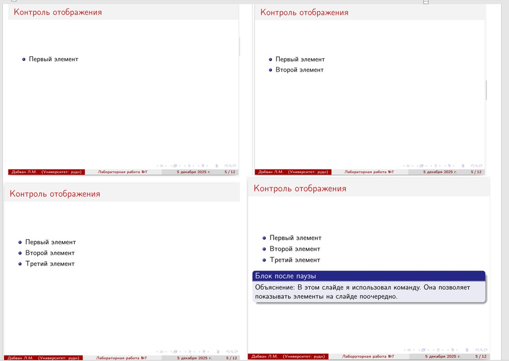

## Математика — Математические формулы

```latex
\section{Математика}
\begin{frame}{Математические формулы}
Формула в тексте: $E = mc^2$
\vspace{0.5cm}
Отдельная формула:
\[
\int_{0}^{1} x^2 \, dx = \frac{1}{3}
\]
\vspace{0.5cm}
Нумерованная формула:
\begin{equation}
\frac{d}{dx}(x^n) = n x^{n-1}
\end{equation}
\end{frame}
```

## Результат:

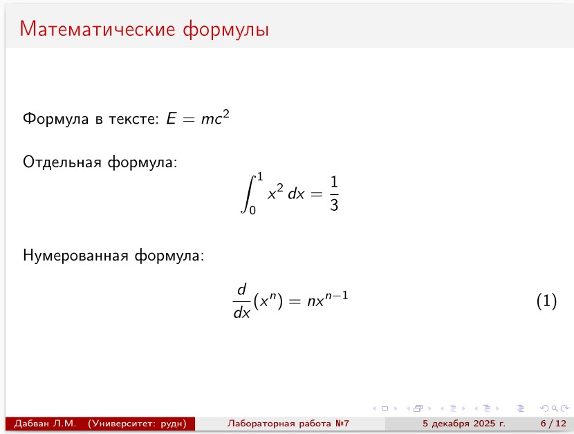

## Выровненные уравнения

```latex
\begin{frame}{Выровненные уравнения}
\begin{align*}
f(x) &= x^2 + 2x + 1 \\

g(x) &= \sin(x) + \cos(x) \\
h(x) &= \frac{1}{1 + e^{-x}}
\end{align*}
\end{frame}
```

## Результат:

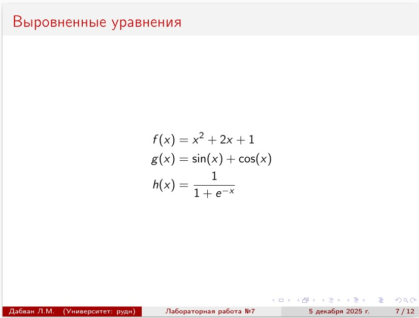

## Изображения в презентациях

Мы используем команду \includegraphics, которая позволяет добавлять изображения в слайды с нужными размерами. Это помогает сделать презентацию более наглядной и привлекательной.

```latex
\begin{frame}{Изображения в презентациях}
\begin{center}
\includegraphics[width=0.5\textwidth]{image_01.jpg}
\captionof{figure}{Пример изображения}
\end{center}
\end{frame}
```

## Результат:

[figure not shown]

## таблицы в презентациях

```latex
\begin{frame}{Таблицы в Beamer}
\begin{center}
\begin{tabular}{lcc}
\toprule
Предмет & Количество & Цена \\
\midrule
Книги & 5 & 2500 руб. \\
Ручки & 10 & 500 руб. \\
Блокноты & 3 & 900 руб. \\
\bottomrule
\end{tabular}
\end{center}
\end{frame}
```

## Результат:

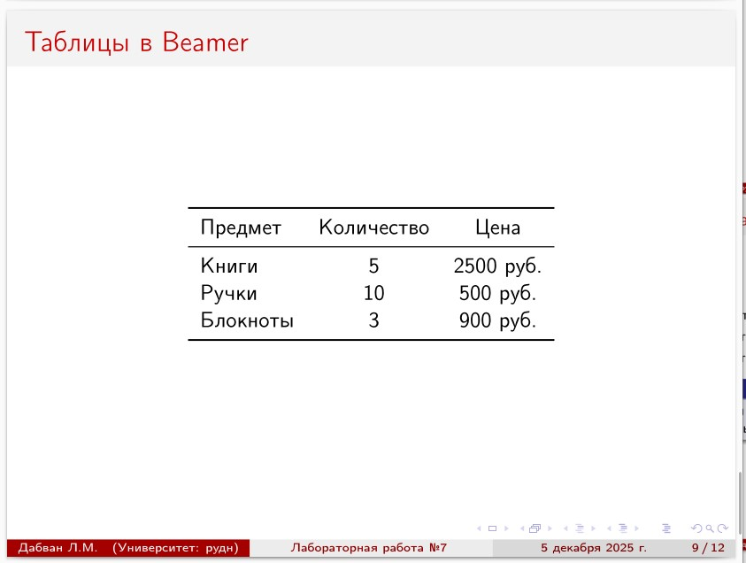

## Советы — Полезные советы

```latex
\section{Советы}
\begin{frame}{Полезные советы}
\begin{enumerate}
\item Одна идея на слайд
\item Используйте изображения
\item Минимизируйте текст
\item Практикуйтесь
\item Следите за временем
\end{enumerate}
\end{frame}
```

## Результат:

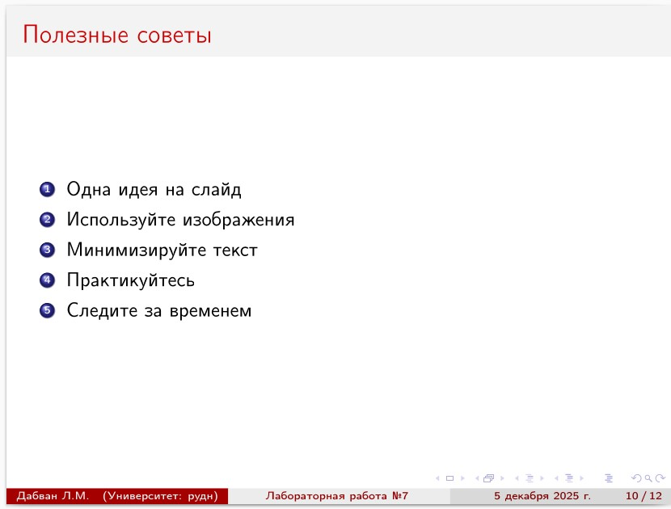

# Анализ и практическая значимость достигнутых результатов

## Анализ полученных результатов показывает следующее:

В результате работы было установлено, что Beamer предоставляет множество преимуществ для создания научных презентаций. Он позволяет создавать точные и профессионально оформленные слайды, что значительно ускоряет процесс подготовки.

## Практическая значимость работы заключается в том, что освоенные методы позволяют:

Практическая значимость заключается в том, что Beamer позволяет создавать качественные научные презентации быстро и эффективно, с высоким уровнем точности в форматировании, особенно для технических и научных работ.

# Выводы по проделанной работе

В рамках лабораторной работы №7 мы изучили процесс создания научных презентаций с использованием LaTeX и пакета Beamer. Работа включала в себя освоение основ Beamer, создание примеров презентаций, использование различных элементов (таких как блоки, списки, изображения, математические формулы и таблицы) .